# R for Improvers (Script 2): Reshaping and summarising data frames

Axel Nohturfft (anohturf@sgul.ac.uk)

2020-04-22

*Please follow the instructions in the README file before starting this tutorial.*

## Introduction: the ‘tidy data’ concept

A lot of effort during data analysis projects goes into shaping input data into a format that can then be analysed with standard tools, a process known as ‘[data wrangling](https://en.wikipedia.org/wiki/Data_wrangling)’ or ‘data munging’.

For example, the same exam results can be tabulated in the following two formats:

|  | Question_1 | Question_2 | Question_3 | Question_4 |
| --- | --- | --- | --- | --- |
| Student_a | A | C | B | E |
| Student_b | A | B | D | E |
| Student_c | A | C | D | B |

| Student | Question | Answer |
| --- | --- | --- |
| a | 1 | A |
| a | 2 | C |
| a | 3 | B |
| a | 4 | E |
| b | 1 | A |
| b | 2 | B |
| b | 3 | D |
| b | 4 | E |
| c | 1 | A |
| c | 2 | C |
| c | 3 | D |
| c | 4 | B |

The first table can be referred to as **wide format**, and the second version can be called the **long format**.

*The term **TIDY DATA** is used in reference to tables arranged in such a way that each row represents an individual sample, and each column represents a variable.*

In the first table above the four question columns all contain the same type of data - students’ answers to multiple choice questions. Plus, the row and column headers contain variables (student and question IDs); this table is *not* ‘tidy’.

The data would have to be converted into the format of the second (long-format) table to be conveniently analysed.

A whole collection of R packages known as the [tidyverse](https://www.tidyverse.org/) are built around the tidy data concept ([Wickham, 2013](https://www.jstatsoft.org/index.php/jss/article/view/v059i10/v59i10.pdf)). These packages are very widely used in the R community.

## Objective

In this part of the workshop we will use two examples to illustrate how to convert data from a wide to a long (tidy) arrangement and how such data can then be summarised in tabular or graphical format.

## Code

### Setup

```r
# clear all variables that might be stored from a previous analysis:
rm(list=ls(all=T))
```

```r
# load packages
library(magrittr)
# help(package="magrittr")
library(readr)
# help(package="readr")
library(dplyr)
# help(package="dplyr")
library(tidyr)
# help(package="tidyr")
library(stringr)
# help(package="stringr")
library(ggplot2)
# help(package="ggplot2")
```

### Time curve of phosphate data

*(Data kindly provided by Felix Effah)*  
Load the original data. If you check the CSV file in Excel, you will notice that the first column does not have a header, so R makes one up (“X1”).

```r
phosphate <- readr::read_csv("data/phosphate.csv")
# View(phosphate)
print(phosphate)
```

| X1 | group | t0 | t0.5 | t1 | t1.5 | t2 | t3 | t4 | t5 |
| --- | --- | --- | --- | --- | --- | --- | --- | --- | --- |
| 1 | control | 4.3 | 3.3 | 3.0 | 2.6 | 2.2 | 2.5 | 3.4 | 4.4 |
| 2 | control | 3.7 | 2.6 | 2.6 | 1.9 | 2.9 | 3.2 | 3.1 | 3.9 |
| 3 | control | 4.0 | 4.1 | 3.1 | 2.3 | 2.9 | 3.1 | 3.9 | 4.0 |
| 4 | control | 3.6 | 3.0 | 2.2 | 2.8 | 2.9 | 3.9 | 3.8 | 4.0 |
| 5 | control | 4.1 | 3.8 | 2.1 | 3.0 | 3.6 | 3.4 | 3.6 | 3.7 |
| 6 | control | 3.8 | 2.2 | 2.0 | 2.6 | 3.8 | 3.6 | 3.0 | 3.5 |
| 7 | control | 3.8 | 3.0 | 2.4 | 2.5 | 3.1 | 3.4 | 3.5 | 3.7 |
| 8 | control | 4.4 | 3.9 | 2.8 | 2.1 | 3.6 | 3.8 | 4.0 | 3.9 |
| 9 | control | 5.0 | 4.0 | 3.4 | 3.4 | 3.3 | 3.6 | 4.0 | 4.3 |
| 10 | control | 3.7 | 3.1 | 2.9 | 2.2 | 1.5 | 2.3 | 2.7 | 2.8 |

[output cut: 23 more lines]

The first column contains just row numbers, so we can remove it:

```r
phosphate.2 <- phosphate %>%
  dplyr::select(-X1)
# View(phosphate.2)
print(phosphate.2)
```

| group | t0 | t0.5 | t1 | t1.5 | t2 | t3 | t4 | t5 |
| --- | --- | --- | --- | --- | --- | --- | --- | --- |
| control | 4.3 | 3.3 | 3.0 | 2.6 | 2.2 | 2.5 | 3.4 | 4.4 |
| control | 3.7 | 2.6 | 2.6 | 1.9 | 2.9 | 3.2 | 3.1 | 3.9 |
| control | 4.0 | 4.1 | 3.1 | 2.3 | 2.9 | 3.1 | 3.9 | 4.0 |
| control | 3.6 | 3.0 | 2.2 | 2.8 | 2.9 | 3.9 | 3.8 | 4.0 |
| control | 4.1 | 3.8 | 2.1 | 3.0 | 3.6 | 3.4 | 3.6 | 3.7 |
| control | 3.8 | 2.2 | 2.0 | 2.6 | 3.8 | 3.6 | 3.0 | 3.5 |
| control | 3.8 | 3.0 | 2.4 | 2.5 | 3.1 | 3.4 | 3.5 | 3.7 |
| control | 4.4 | 3.9 | 2.8 | 2.1 | 3.6 | 3.8 | 4.0 | 3.9 |
| control | 5.0 | 4.0 | 3.4 | 3.4 | 3.3 | 3.6 | 4.0 | 4.3 |
| control | 3.7 | 3.1 | 2.9 | 2.2 | 1.5 | 2.3 | 2.7 | 2.8 |

[output cut: 23 more lines]

The values in columns t0 to t5 all contain the same type of data - phosphate concentrations. Let’s convert the table to a tidy (long) format using the `pivot_longer()` function from the ‘[tidyr](https://tidyr.tidyverse.org/)’ package.

```r
phosphate.3 <- phosphate.2 %>%
  tidyr::pivot_longer(-group, names_to = "Time", values_to = "Phosphate")
# View(phosphate.3)
print(phosphate.3)
```

| group | Time | Phosphate |
| --- | --- | --- |
| control | t0 | 4.3 |
| control | t0.5 | 3.3 |
| control | t1 | 3.0 |
| control | t1.5 | 2.6 |
| control | t2 | 2.2 |
| control | t3 | 2.5 |
| control | t4 | 3.4 |
| control | t5 | 4.4 |
| control | t0 | 3.7 |
| control | t0.5 | 2.6 |

[output cut: 254 more lines]

For easier inspection let’s sort the data frame by group and time:

```r
phosphate.4 <- phosphate.3 %>%
  dplyr::rename(Group = group) %>%
  dplyr::arrange(Group, Time)
# View(phosphate.4)
print(phosphate.4)
```

| Group | Time | Phosphate |
| --- | --- | --- |
| control | t0 | 4.3 |
| control | t0 | 3.7 |
| control | t0 | 4.0 |
| control | t0 | 3.6 |
| control | t0 | 4.1 |
| control | t0 | 3.8 |
| control | t0 | 3.8 |
| control | t0 | 4.4 |
| control | t0 | 5.0 |
| control | t0 | 3.7 |

[output cut: 254 more lines]

The letter ‘t’ in the Time column is redundant and would prevent us from plotting the data on a numerical time axis. Next we remove the letter ‘t’ and convert the column to numeric format:

```r
phosphate.5 <- phosphate.4 %>%
  dplyr::mutate(Time = stringr::str_remove(Time, "t")) %>%
  dplyr::mutate(Time = as.numeric(Time))
# View(phosphate.5)
print(phosphate.5)
```

| Group | Time | Phosphate |
| --- | --- | --- |
| control | 0.0 | 4.3 |
| control | 0.0 | 3.7 |
| control | 0.0 | 4.0 |
| control | 0.0 | 3.6 |
| control | 0.0 | 4.1 |
| control | 0.0 | 3.8 |
| control | 0.0 | 3.8 |
| control | 0.0 | 4.4 |
| control | 0.0 | 5.0 |
| control | 0.0 | 3.7 |

[output cut: 254 more lines]

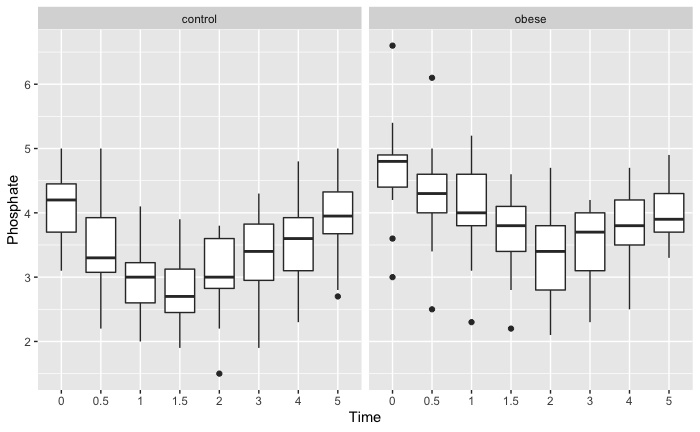

```r
gg1 <- phosphate.5 %>%
  dplyr::mutate(Time = factor(Time, levels=sort(unique(phosphate.5$Time)))) %>%
  ggplot(aes(x=Time, y=Phosphate)) + geom_boxplot() + facet_wrap(~Group)
gg1
```

Alternatively, one might want to calculate averages for each time point and display the data as a scatterplot.  
In this case we first use the `group_by()` and `summarise()` functions from the tidyverse ‘dplyr’ package:

```r
phosphate.6 <- phosphate.5 %>%
  dplyr::group_by(Group, Time) %>%
  dplyr::summarise(Average = mean(Phosphate),
                   SD = sd(Phosphate)) %>%
  dplyr::mutate(lower = Average - SD,
                upper = Average + SD)
# View(phosphate.6)
dplyr::select(phosphate.6, -lower, -upper)
```

| Group | Time | Average | SD |
| --- | --- | --- | --- |
| control | 0.0 | 4.150000 | 0.5155477 |
| control | 0.5 | 3.505000 | 0.7472581 |
| control | 1.0 | 2.950000 | 0.5414406 |
| control | 1.5 | 2.785000 | 0.5294237 |
| control | 2.0 | 3.000000 | 0.6223893 |
| control | 3.0 | 3.300000 | 0.7159829 |
| control | 4.0 | 3.565000 | 0.6698586 |
| control | 5.0 | 3.960000 | 0.6081897 |
| obese | 0.0 | 4.676923 | 0.8584422 |
| obese | 0.5 | 4.238462 | 0.8549254 |

[output cut: 6 more lines]

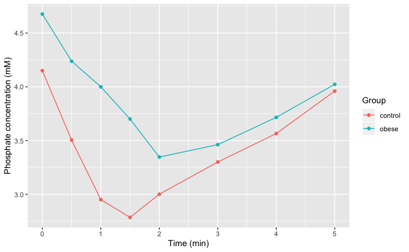

```r
gg2 <- phosphate.6 %>%
  ggplot(aes(x=Time, y=Average, color=Group)) +
  geom_line() +
  # geom_errorbar(aes(ymin=lower, ymax=upper, width=0.1)) +
  geom_point() +
  labs(x="Time (min)",
       y="Phosphate concentration (mM)")
gg2
```

In “real life” one would have processed the phosphate data in one continuous chain of pipes:

```r
phosphate.x <- readr::read_csv("data/phosphate.csv") %>%
  dplyr::select(-X1) %>%
  tidyr::pivot_longer(-group, names_to = "Time", values_to = "Phosphate") %>%
  dplyr::rename(Group = group) %>%
  dplyr::arrange(Group, Time) %>%
  dplyr::mutate(Time = stringr::str_remove(Time, "t")) %>%
  dplyr::mutate(Time = as.numeric(Time))

phosphate.summary <- phosphate.x %>%
  dplyr::group_by(Group, Time) %>%
  dplyr::summarise(Average = mean(Phosphate),
                   SD = sd(Phosphate)) %>%
  dplyr::mutate(lower = Average - SD,
                upper = Average + SD)
```

### Merging / joining data frames

A very common task. One example would be to have two tables: one with gene symbols and expression data, and another with the gene symbols and gene names - your goal would be to add the gene names to expression data.  
In general programming parlance people refer to this as performing a **join**.  
The function we use in base R is `merge()`.  
The ‘dplyr’ package also provides a number of join function that work well with magrittr pipes and other tidyverse functions.

Here, let’s go back to our exam files from the first script…

#### Step 1: Load the blueprint file and select the relevant columns

```r
csv.file <- "data/OSPE_Blueprint.csv"
stopifnot(file.exists(csv.file))
df.blueprint <- readr::read_csv(file=csv.file, col_names = TRUE, comment = "#") %>%
  dplyr::select(Question, Correct_Answer)
print(df.blueprint)
```

| Question | Correct_Answer |
| --- | --- |
| OSPE1 | C |
| OSPE2 | A |
| OSPE3 | E |
| OSPE4 | A |
| OSPE5 | C |

#### Step 2: Load the file with the student answers

```r
tsv.file <- "data/OSPE_Results_Raw.tsv"
stopifnot(file.exists(tsv.file))
df.results <- readr::read_tsv(file=tsv.file, col_names = TRUE, comment = "#")
print(df.results)
```

| Cand.No | OSPE1 | OSPE2 | OSPE3 | OSPE4 | OSPE5 |
| --- | --- | --- | --- | --- | --- |
| 1001 | C | A | B | A | C |
| 1002 | C | A | E | A | C |
| 1003 | C | C | E | A | B |
| 1004 | C | A | E | A | A |
| 1005 | C | A | E | A | C |
| 1006 | C | A | E | A | B |
| 1007 | B | A | E | A | B |
| 1008 | C | A | E | A | C |
| 1009 | C | A | E | A | C |
| 1010 | C | A | E | A | C |

#### Step 3: Reshape student answers into ‘tidy’ (long) format

```r
results.long <- tidyr::pivot_longer(df.results, -Cand.No, names_to = "Question", values_to = "Answer")
print(results.long)
```

| Cand.No | Question | Answer |
| --- | --- | --- |
| 1001 | OSPE1 | C |
| 1001 | OSPE2 | A |
| 1001 | OSPE3 | B |
| 1001 | OSPE4 | A |
| 1001 | OSPE5 | C |
| 1002 | OSPE1 | C |
| 1002 | OSPE2 | A |
| 1002 | OSPE3 | E |
| 1002 | OSPE4 | A |
| 1002 | OSPE5 | C |

[output cut: 40 more lines]

#### Step 4: Merge results and blueprint

```r
df.merged <- merge(x=results.long, y=df.blueprint, by="Question") %>%
  dplyr::select(Cand.No, everything()) %>%
  dplyr::arrange(Cand.No, Question)
print(df.merged)
```

| Cand.No | Question | Answer | Correct_Answer |
| --- | --- | --- | --- |
| 1001 | OSPE1 | C | C |
| 1001 | OSPE2 | A | A |
| 1001 | OSPE3 | B | E |
| 1001 | OSPE4 | A | A |
| 1001 | OSPE5 | C | C |
| 1002 | OSPE1 | C | C |
| 1002 | OSPE2 | A | A |
| 1002 | OSPE3 | E | E |
| 1002 | OSPE4 | A | A |
| 1002 | OSPE5 | C | C |

[output cut: 40 more lines]

#### Step 5: “Mark” the answers

```r
df.marked <- df.merged %>%
  dplyr::mutate(Answer_Correct = (Answer == Correct_Answer))
print(df.marked)
```

| Cand.No | Question | Answer | Correct_Answer | Answer_Correct |
| --- | --- | --- | --- | --- |
| 1001 | OSPE1 | C | C | TRUE |
| 1001 | OSPE2 | A | A | TRUE |
| 1001 | OSPE3 | B | E | FALSE |
| 1001 | OSPE4 | A | A | TRUE |
| 1001 | OSPE5 | C | C | TRUE |
| 1002 | OSPE1 | C | C | TRUE |
| 1002 | OSPE2 | A | A | TRUE |
| 1002 | OSPE3 | E | E | TRUE |
| 1002 | OSPE4 | A | A | TRUE |
| 1002 | OSPE5 | C | C | TRUE |

[output cut: 40 more lines]

## EXERCISE

1. Using the `df.marked` data above, calculate a percentage mark for each student (Cand.No).
2. Calculate the percent facility for each of the five exam questions (percentage of students who got the answer right).